# Introduction

## Core tidyverse

Some quotes and concepts [from Hadley Wickham](https://cran.r-project.org/web/packages/tidyr/vignettes/tidy-data.html) that we may want to include in the intro…

#### Data semantics

> A dataset is a collection of values, usually either numbers (if quantitative) or strings (if qualitative). Values are organised in two ways. Every value belongs to a variable and an observation. A variable contains all values that measure the same underlying attribute (like height, temperature, duration) across units. An observation contains all values measured on the same unit (like a person, or a day, or a race) across attributes.

> The experimental design also determines whether or not missing values can be safely dropped. In this experiment, the missing value represents an observation that should have been made, but wasnât, so itâs important to keep it. Structural missing values, which represent measurements that canât be made (e.g., the count of pregnant males) can be safely removed.

> A general rule of thumb is that it is easier to describe functional relationships between variables (e.g., z is a linear combination of x and y, density is the ratio of weight to volume) than between rows, and it is easier to make comparisons between groups of observations (e.g., average of group a vs. average of group b) than between groups of columns.

#### Tidy data

> Tidy data is a standard way of mapping the meaning of a dataset to its structure. A dataset is messy or tidy depending on how rows, columns and tables are matched up with observations, variables and types. In tidy data: 1. Each variable forms a column. 2. Each observation forms a row. 3. Each type of observational unit forms a table.

> This is Coddâs 3rd normal form, but with the constraints framed in statistical language, and the focus put on a single dataset rather than the many connected datasets common in relational databases. Messy data is any other arrangement of the data.

> > Alternate Definition [from Garrett Grolemund](http://garrettgman.github.io/tidying/)

> > R follows a set of conventions that makes one layout of tabular data much easier to work with than others. Your data will be easier to work with in R if it follows three rules 1. Each variable in the data set is placed in its own column 2. Each observation is placed in its own row 3. Each value is placed in its own cell*

> > Data that satisfies these rules is known as tidy data.

> five most common problems with messy datasets…: 1. Column headers are values, not variable names. 2. Multiple variables are stored in one column. 3. Variables are stored in both rows and columns. 4. Multiple types of observational units are stored in the same table. 5. A single observational unit is stored in multiple tables.

#### Normalization

> Normalisation is useful for tidying and eliminating inconsistencies. However, there are few data analysis tools that work directly with relational data, so analysis usually also requires denormalisation or the merging the datasets back into one table.

## Workflow tutorial on using `tidyverse` to process data

This workflow tutorial demonstrates how to process data from start to finish using `tidyverse`.

In this tutorial, we will do the following:

1. Use `readr` package to read a csv file.
2. Use `tidyr` package to transform data into tidy data.
3. Use `dplyr` package to group and summarize data.
4. Use `ggplot2` package to visualize data.

### About the data set

This data file was taken from https://data.fivethirtyeight.com/ under data set `uber-tlc-foil-response`. This specific data was taken from an Excel file named `Uber Weekday-Hour AverageTrips.xlsx` under a sheet entitled `Trips Per Hour and Weekday`.

```r
file <- "https://raw.githubusercontent.com/Shetura36/Data-607-Assignments/master/Bookdown/Uber%20Weekday-Hour%20AverageTrips.csv"
```

### Load libraries for this tutorial

```r
library(tidyverse)
library(knitr)
```

### 1. Read file with `readr` package

The code below demonstrates how to use the `readr::read_csv`, which is part of the`tidyverse`.

- `file` is a variable that contains the file path of the data set.
- `skip` indicates the number of lines to skip before reading data.
- `col_names` is either TRUE or FALSE or a character vector of column names.

The code below skips the first two rows of data. If you take a look at the data file, the first row provides a description of the five columns into two groups: `Time`and `Average trips per hour and day of week`. The second row provides the column names; however, the code below will explicitly provide the column names. These two rows from the raw data file are skipped.

```r
col_names <- c("weekday", "hour", "other_8_bases", "uber", "lyft")
data <- readr::read_csv(file, skip = 2, col_names)
```

### Preview data set

Below is a preview of the data set.

| weekday | hour | other_8_bases | uber | lyft |
| --- | --- | --- | --- | --- |
| 1 | 0 | 769 | 1458 | 323 |
| 1 | 1 | 645 | 1078 | 344 |
| 1 | 2 | 497 | 757 | 362 |
| 1 | 3 | 385 | 513 | 362 |
| 1 | 4 | 435 | 308 | 333 |
| 1 | 5 | 438 | 308 | 297 |

### 2. Transform data so that each observation represents a car service

The code below uses `tidyr` package to transform data so that each row represents a car service. The transformation will take the columns `uber`, `lyft`, and `other_8_bases` and assign them to a column named `car_service`. It will also create a column called `average_trip_per_hrday` to store the values that used to be stored in the three columns mentioned. The last parameter (`3:5`) indicates the columns that will be renamed as `car_service`.

```r
data_transform <- tidyr::gather(data, "car_service", "average_trip_per_hrday", 3:5)
```

### Preview of transformed data

Below is a preview of the data that has been transformed.

| weekday | hour | car_service | average_trip_per_hrday |
| --- | --- | --- | --- |
| 1 | 0 | other_8_bases | 769 |
| 1 | 1 | other_8_bases | 645 |
| 1 | 2 | other_8_bases | 497 |
| 1 | 3 | other_8_bases | 385 |
| 1 | 4 | other_8_bases | 435 |
| 1 | 5 | other_8_bases | 438 |

### 3. Use `dplyr` to calculate the average number of trips per hour for each car service

The `group_by` function groups the rows by `car_service`, and then by `hour`. The `summarise` function is used to calculate the mean of the `average_trip_per_hrday` based on the grouping mentioned. Basically, what this does is group all hours across all different days for each car service. The `arrange` function then orders the result by `car_service` and `hour`.

```r
average_trips_perhour <-
data_transform %>%
  dplyr::group_by(car_service, hour) %>%
  dplyr::summarise(average_trips = mean(average_trip_per_hrday)) %>%
  arrange(car_service, hour)
```

### Preview of `average_trips_perhour`

Below is a preview of the summarized data for `average_trips_perhour`, which is the average number of trips for the hour in military time for each car service.

| car_service | hour | average_trips |
| --- | --- | --- |
| lyft | 0 | 299.1429 |
| lyft | 1 | 296.0000 |
| lyft | 2 | 287.0000 |
| lyft | 3 | 263.1429 |
| lyft | 4 | 206.0000 |
| lyft | 5 | 152.5714 |

### 4. Use `ggplot2` to visualize data

The plot below shows the average number of trips per hour for each car service.

`ggplot` function is used to plot a scatter plot and generate a loess regression line. `geom_smooth` is used to generate the regression line.

Arguments for `geom_smooth`:

- method : smoothing method to be used. Possible values are lm, glm, gam, loess, rlm.
- method = “loess”: This is the default value for small number of observations. It computes a smooth local regression. You can read more about loess using the R code ?loess.
- method =“lm”: It fits a linear model. Note that, it’s also possible to indicate the formula as - formula = y ~ poly(x, 3) to specify a degree 3 polynomial.
- se : logical value. If TRUE, confidence interval is displayed around smooth.
- fullrange : logical value. If TRUE, the fit spans the full range of the plot
- level : level of confidence interval to use. Default value is 0.95

source: http://www.sthda.com/english/wiki/ggplot2-scatter-plots-quick-start-guide-r-software-and-data-visualization

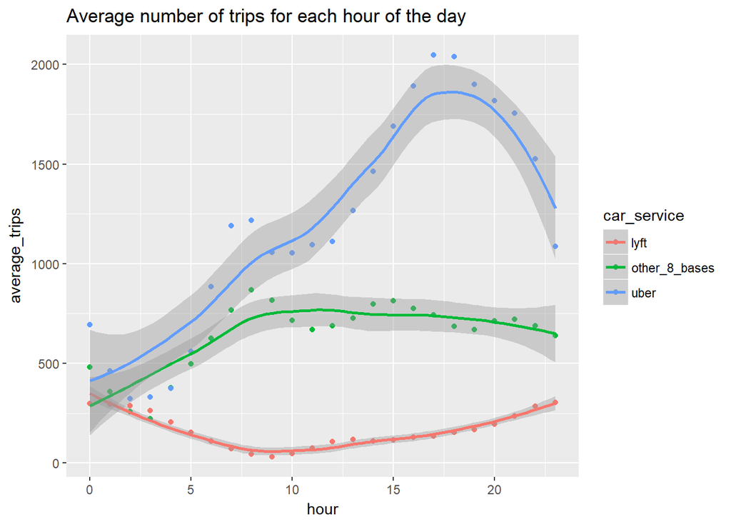

```r
ggplot(average_trips_perhour, aes(x=hour, y=average_trips, color=car_service)) + geom_point() +
  geom_smooth(method="loess", se=TRUE, fullrange=FALSE, level=0.95) +
  ggtitle("Average number of trips for each hour of the day")
```